# Project Component 3 — Example

Roots of the Proto-Indo-European Lexicon: A First Look at Pokorny’s Roots

Author

Dr. Andrew M. Byrd

**Note**

This is my own Component 3, written as a model for yours. It picks up where [my Component 2](https://winjapati.github.io/courses/301/project2_example_byrd.html) left off: a clean table of 2,077 roots from Pokorny’s dictionary. As before, my data is unusual, so focus on the overall shape: plan, load and check, add columns, count, chart, explain.

## 1. Analysis Plan

In Component 1 I asked four questions about Pokorny’s roots. Here I’m taking on two of them. First: **which sounds begin PIE roots, and is *b* really as rare as handbooks say?** I expect *b* to be the rarest of the plain stops at the start of a root, far rarer than *p* or *bh*. Second: **which branches of Indo-European does Pokorny cite most often?** I expect Indo-Iranian, Greek, Latin, and Germanic at the top, since those are the classic languages of 19th-century comparative grammar, and Anatolian (Hittite) and Tocharian at the bottom, since they were only deciphered in the early 20th century and were still new when Pokorny was writing.

## 2. Data Check

I start from my Component 2 `.csv`, not from the web page:

```python
import re
import pandas as pd
import matplotlib.pyplot as plt

df = pd.read_csv("project2_byrd_andrew.csv")

print(len(df))
df.head()
```

```
2077
```

|  | entry | forms | english | german | material | page |
| --- | --- | --- | --- | --- | --- | --- |
| 0 | 1 | ā | interjection | Ausruf der Empfindung | Ai. ā Ausruf der Besinnung; gr. ἆ Ausruf des U... | 1 |
| 1 | 2 | ab- | water, river | Wasser, Fluß | Lat. amnis f., später m. c(*abnis); air. ab (*... | 1 |
| 2 | 3 | ā̆bel-, ā̆bōl-, abel- | apple | Apfel | Lat. Abella (osk. Stadt in Campanien) malifera... | 1 |
| 3 | 4 | abh- | quick, abrupt | rasch, heftig | Gr. ἄφαρ ‘sogleich’ (altes Abstraktum ‘Schnell... | 2 |
| 4 | 5 | abhro- | strong, mighty | stark, heftig | Mir. Präfix abor-, cymr. afr- ‘sehr’; got. abr... | 2 |

```python
df.tail()
```

|  | entry | forms | english | german | material | page |
| --- | --- | --- | --- | --- | --- | --- |
| 2072 | 2216 | u̯reg- (und u̯erg-?) | to push, drag, drive | stoßen, drängen, puffen, treiben, feindselig v... | Ai. vielleicht vrájati ‘schreitet, geht’, pra-... | 1181 |
| 2073 | 2217 | u̯rēĝ-, u̯rōĝ-, u̯rəĝ- | to break | brechen | Arm. ergic-uc̣anem (*u̯rēĝ-) ‘ῥήγνυμι’; gr. ῥή... | 1181 |
| 2074 | 2220 | u̯ren- | to sprinkle | bespritzen, besprengen? | Gr. ῥαίνω (*u̯r̥ni̯ō) ‘bespritze, besprenge (m... | 1182 |
| 2075 | 2221 | (u̯reth- :) u̯roth- oder u̯rath- | to support | stützen? | Ags. wraðu f. ‘Stütze’, wreðian ‘stützen’, as.... | 1183 |
| 2076 | 2222 | u̯rughi̯o- | rye | Roggen | Thrak. βρίζα (*u̯rughi̯ā) ‘Emmerkorn, Roggen’;... | 1183 |

2,077 rows and six columns, the same as when I saved it. In my Component 2 *Still Messy* list I named a few problems. Two of them get in the way of my questions here, so I fix them in the analyses below:

- **Several forms per entry.** To ask how a root begins, I need one form per root (Analysis 1).
- **The material is unstructured**, and languages are marked only by abbreviations. I need a lookup table from abbreviation to branch (Analysis 2).

The others (subscript letters, the varied English meanings) don’t affect these two questions, so I’m leaving them for later.

## 3. Analysis 1: How Do PIE Roots Begin?

### Picking one form per root

The `forms` column often has several forms, separated by commas, colons, or semicolons:

```python
df["forms"].head(12)
```

```
0                         ā
1                       ab-
2     ā̆bel-, ā̆bōl-, abel-
3                      abh-
4                    abhro-
5                    abō(n)
6                      ad-1
7                      ad-2
8              ades-, ados-
9            ad(u)-, ad-ro-
10                      aĝ-
11                     ā̆ĝ-
Name: forms, dtype: str
```

Pokorny lists his main form first, so I keep everything before the first `,`, `:`, or `;`. I also take out two kinds of notation that would get in the way:

- The **s-mobile**, written `(s)`, as in `(s)kel-`. This is an *s* that shows up in some daughter languages and not others. I want to know what the root itself starts with, so I remove it: `(s)kel-` counts as a *k*-root.
- Other **parentheses, brackets, and asterisks**, which Pokorny uses for doubtful or optional parts (`(demə-)`, `lē[i]-`, `*gʷhēi-`). I keep the letters inside and drop the marks.

I write this as a function, so I can use it in a list comprehension to make a new column:

```python
def first_form(forms):
    form = re.split(r"[,:;]", forms)[0]
    for mark in ["(s)", "(", ")", "[", "]", "*"]:
        form = form.replace(mark, "")
    return form.strip()

df["root"] = [first_form(f) for f in df["forms"]]
df[["forms", "root"]].head(12)
```

|  | forms | root |
| --- | --- | --- |
| 0 | ā | ā |
| 1 | ab- | ab- |
| 2 | ā̆bel-, ā̆bōl-, abel- | ā̆bel- |
| 3 | abh- | abh- |
| 4 | abhro- | abhro- |
| 5 | abō(n) | abōn |
| 6 | ad-1 | ad-1 |
| 7 | ad-2 | ad-2 |
| 8 | ades-, ados- | ades- |
| 9 | ad(u)-, ad-ro- | adu- |
| 10 | aĝ- | aĝ- |
| 11 | ā̆ĝ- | ā̆ĝ- |

*What this costs me:* about 80 roots, like `(s)kel-`, now count as *k*-roots, not *s*-roots. That’s the choice that fits my question, but it means my *s* count is lower than Pokorny’s own alphabetical order would suggest.

### Finding the first sound

The first *character* isn’t always the first *sound*. In Pokorny’s notation, `bh`, `gʷ`, and `k̂` are each one sound, written with more than one character. So I make a list of these multi-character sounds and check them first. The longest ones (`gʷh`) have to come before the shorter ones they start with (`gʷ`), or `gʷh-` would be counted as `gʷ`.

```python
multi = ["gʷh", "ĝh", "k̂h", "gʷ", "kʷ", "bh", "dh", "gh",
         "ph", "th", "kh", "k̂", "u̯", "i̯"]

def first_sound(root):
    for sound in multi:
        if root.startswith(sound):
            return sound
    return root[0]

df["first_sound"] = [first_sound(r) for r in df["root"]]
df[["root", "first_sound"]].head(12)
```

|  | root | first_sound |
| --- | --- | --- |
| 0 | ā | ā |
| 1 | ab- | a |
| 2 | ā̆bel- | ā |
| 3 | abh- | a |
| 4 | abhro- | a |
| 5 | abōn | a |
| 6 | ad-1 | a |
| 7 | ad-2 | a |
| 8 | ades- | a |
| 9 | adu- | a |
| 10 | aĝ- | a |
| 11 | ā̆ĝ- | ā |

Now I can count:

```python
df["first_sound"].value_counts().head(25)
```

```
first_sound
s     212
k     187
m     141
u̯    139
p     133
bh    130
a     125
t     108
l     102
k̂     92
e      80
dh     67
d      57
gh     57
n      53
r      52
g      50
ĝh     44
gʷ     36
b      28
i̯     28
o      27
kʷ     24
ĝ      22
ē      18
Name: count, dtype: int64
```

### The stops

My question is really about the **stops**, the consonants like *p*, *t*, *k*. PIE is usually reconstructed with three series of them: plain voiceless (*p*), plain voiced (*b*), and voiced aspirated (*bh*), at five places in the mouth. Here are the counts for all fifteen:

```python
stops = ["p", "b", "bh",
         "t", "d", "dh",
         "k̂", "ĝ", "ĝh",
         "k", "g", "gh",
         "kʷ", "gʷ", "gʷh"]

counts = df["first_sound"].value_counts()
stop_counts = [counts[s] for s in stops]

for s in stops:
    print(s, counts[s])
```

```
p 133
b 28
bh 130
t 108
d 57
dh 67
k̂ 92
ĝ 22
ĝh 44
k 187
g 50
gh 57
kʷ 24
gʷ 36
gʷh 12
```

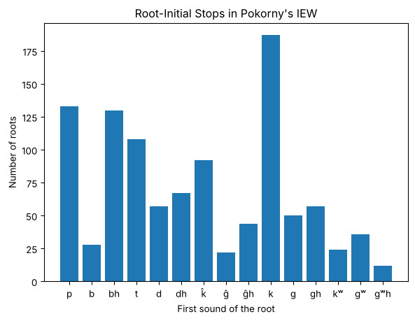

```python
plt.bar(stops, stop_counts)
plt.title("Root-Initial Stops in Pokorny's IEW")
plt.xlabel("First sound of the root")
plt.ylabel("Number of roots")
plt.show()
```

*b* is rare, but it isn’t actually the rarest: *ĝ* has only 22 roots to *b*’s 28. That’s not what I predicted. But *ĝ* is part of a row that’s small across the board (the palatals), while *b* sits next to two of the biggest columns in the chart: 133 *p*-roots and 130 *bh*-roots. *b* has less than a quarter as many roots as either of its neighbors. At every other place, the plain voiced stop has at least half as many roots as the aspirate (*d* 57 vs. *dh* 67, *g* 50 vs. *gh* 57). The gap at the lips is real.

What are those 28 *b*-roots?

```python
b_roots = df[df["first_sound"] == "b"]
b_roots[["entry", "forms", "english"]]
```

|  | entry | forms | english |
| --- | --- | --- | --- |
| 142 | 149 | bab-, bhabh-, pap- | to swell |
| 143 | 150 | baba- | barbaric speech |
| 144 | 151 | badi̯os | gold, brown |
| 145 | 152 | baitā oder paitā? | goatskin |
| 146 | 153 | bak- | stick, to hit |
| 147 | 154 | bal-, balbal- | to shake, dance |
| 148 | 156 | bamb- | a k. of noise |
| 149 | 157 | bamb-, bhambh-, pamp-, phamph- | to swell |
| 150 | 158 | band- | drop |
| 151 | 160 | bata- | murmur, babble |
| 152 | 161 | bau | sound of barking |
| 153 | 162 | bdel- | to suck |
| 154 | 163 | bē, bā | sheeps bleating |
| 155 | 164 | bed- | to swell? |
| 156 | 165 | bel-1 | to cut off |
| 157 | 166 | bel-2 | strong |
| 158 | 167 | bend-, bn̥d-no- | spike, needle, etc. |
| 159 | 168 | b(e)u-1, bh(e)u- | expr. sound of hitting |
| 160 | 169 | b(e)u-2, bh(e)ū̆- | to swell, puff |
| 161 | 170 | bis-(t)li- | gall |
| 162 | 171 | blat- | to chat |
| 163 | 172 | blē- | to bleat |
| 164 | 173 | blou- (bhlou-?), plou- | flea |
| 165 | 174 | bol- | tuber |
| 166 | 175 | brangh-, brongh-? | hoarse? |
| 167 | 176 | breuq- | to jump |
| 168 | 177 | bronk- | to lock |
| 169 | 178 | bu- | lip, kiss |

A lot of them aren’t ordinary vocabulary at all. Many are **sound-symbolic**: ‘barbaric speech’, ‘murmur, babble’, ‘sound of barking’, ‘sheep’s bleating’, ‘to bleat’, ‘to chat’, ‘hoarse’, ‘lip, kiss’. Several are ‘to swell’, often listed with variants in *bh-* and *p-* (`bab-, bhabh-, pap-`), which is typical of expressive words. And a few look like loanwords (`badi̯os` ‘gold, brown’). So *b* isn’t just rare: where it does show up, it’s mostly in words that don’t follow the normal sound rules anyway.

## 4. Analysis 2: Which Branches Does Pokorny Cite?

### A lookup table of abbreviations

Pokorny names languages with German abbreviations at the start of each citation: `ai.` (*altindisch*, Sanskrit), `ahd.` (*althochdeutsch*, Old High German), `aksl.` (*altkirchenslavisch*, Old Church Slavonic), and so on. To get from languages to **branches**, I made a dictionary: each key is a branch, and each value is a list of the abbreviations that belong to it. I built the list by counting every short word followed by a period in the material and looking up the common ones in Pokorny’s list of abbreviations.

```python
branches = {
    "Indo-Iranian": ["ai", "av", "ap", "apers", "npers", "osset"],
    "Greek": ["gr", "hom", "att", "dor", "ion"],
    "Italic": ["lat", "alat", "osk", "umbr"],
    "Celtic": ["air", "mir", "nir", "ir", "cymr", "acymr", "mcymr", "ncymr",
               "bret", "abret", "mbret", "nbret", "corn", "acorn", "gall"],
    "Germanic": ["got", "ahd", "mhd", "nhd", "ags", "aisl", "an", "anord",
                 "isl", "nisl", "as", "mnd", "nd", "engl", "mengl", "norw",
                 "schwed", "aschwed", "dän", "afries", "ndl", "mndl", "asächs"],
    "Balto-Slavic": ["lit", "alit", "lett", "apr", "aksl", "ksl", "russ",
                     "aruss", "poln", "čech", "ačech", "serb", "skr",
                     "sloven", "slov", "bulg", "klr"],
    "Armenian": ["arm"],
    "Albanian": ["alb"],
    "Tocharian": ["toch"],
    "Anatolian": ["hitt", "luw", "lyk", "lyd"],
}
```

Two traps I found by checking matches in context. `skr.` is Serbo-Croatian, not Sanskrit (I noted this in Component 2), so it goes in Balto-Slavic. And `pal.` looked like Palaic, an Anatolian language, but in Pokorny it almost always means *palatal*, so I left it out.

### One True/False column per branch

Five roots have no material at all (Component 2, *Still Messy*), so they can’t tell me anything about branches. I set them aside first. `.notna()` is True when a cell is *not* empty (not `NaN`):

```python
has_material = df[df["material"].notna()].copy()
has_material["material_lower"] = has_material["material"].str.lower()
print(len(has_material))
```

```
2072
```

(`.copy()` tells pandas this is a new table of its own, so it doesn’t warn me when I add columns to it.)

Now, for each branch, I build a regular expression that matches any of its abbreviations, and use `.str.contains()` to make a True/False column. `\b` makes sure `ir.` doesn’t match inside `air.`, and `\.` matches an actual period. The `|` joins them: `\bai\.|\bav\.|...`

```python
for branch, abbrevs in branches.items():
    pattern = "|".join([r"\b" + a + r"\." for a in abbrevs])
    has_material[branch] = has_material["material_lower"].str.contains(pattern)

has_material[["entry", "forms", "Greek", "Anatolian", "Tocharian"]].head()
```

|  | entry | forms | Greek | Anatolian | Tocharian |
| --- | --- | --- | --- | --- | --- |
| 0 | 1 | ā | True | False | False |
| 1 | 2 | ab- | False | False | False |
| 2 | 3 | ā̆bel-, ā̆bōl-, abel- | False | False | False |
| 3 | 4 | abh- | True | False | False |
| 4 | 5 | abhro- | False | False | False |

Spot-checking entry 2, *ab-* ‘water, river’: its material cites Latin *amnis*, Old Irish *ab*, Welsh *afon*, German river names in *-affa*, and a Latvian river name, but nothing in Greek, Indo-Iranian, Hittite, or Tocharian. The columns get all of that right.

### What share of roots does each branch attest?

Since every root is either True or False for a branch, the `.mean()` of a column is the share of roots that cite that branch. Times 100, it’s a percentage:

```python
rates = {}
for branch in branches:
    rates[branch] = round(has_material[branch].mean() * 100, 1)

rates = pd.Series(rates).sort_values(ascending=False)
rates
```

```
Germanic        71.4
Balto-Slavic    68.3
Greek           64.0
Indo-Iranian    56.6
Italic          54.1
Celtic          49.2
Armenian        26.3
Albanian        18.3
Tocharian       14.3
Anatolian        9.4
dtype: float64
```

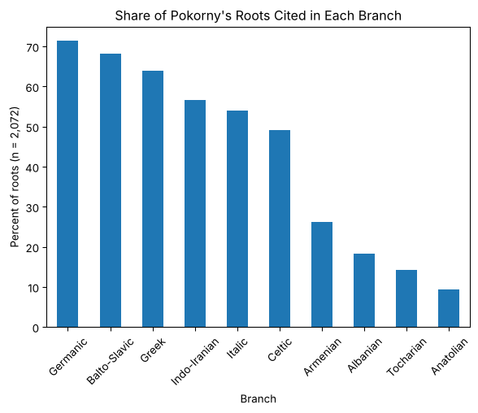

```python
rates.plot(kind="bar")
plt.title("Share of Pokorny's Roots Cited in Each Branch")
plt.xlabel("Branch")
plt.ylabel("Percent of roots (n = 2,072)")
plt.xticks(rotation=45)
plt.show()
```

Germanic comes first (71%), then Balto-Slavic (68%) and Greek (64%), with Indo-Iranian (57%) only fourth. Anatolian is last, at under 10%, and Tocharian is barely ahead of it.

### How many branches per root?

Python counts `True` as 1 and `False` as 0, so if I add up the branch columns for each row, I get the number of branches each root is cited in. `.sum(axis=1)` adds *across* each row instead of down each column, and `.sort_index()` puts the result in order by number of branches instead of by count:

```python
has_material["n_branches"] = has_material[list(branches)].sum(axis=1)
has_material["n_branches"].value_counts().sort_index()
```

```
n_branches
1      24
2     439
3     464
4     318
5     251
6     214
7     170
8     104
9      61
10     27
Name: count, dtype: int64
```

Two or three branches is most common. Only 27 roots are found in all ten, and about two dozen are cited in only one branch.

## 5. Interpretation

I asked two questions of Pokorny’s roots: what sounds they begin with, and which branches of Indo-European he cites for them. To answer them, I added a `root` column with one form per entry and a `first_sound` column using a list of multi-character sounds, then counted with `.value_counts()`; for branches, I built a lookup table of abbreviations and made one True/False column per branch with `.str.contains()`, comparing them as percentages. The *b* result mostly held up: *ĝ* turned out to be slightly rarer, but only 28 roots begin with *b*, under a quarter as many as begin with *p* or *bh*, and most of those 28 are sound-symbolic or expressive words like ‘to bleat’ and ‘babble’. The branch result partly surprised me: Anatolian and Tocharian are at the bottom, as I predicted, but Germanic and Balto-Slavic beat Indo-Iranian, which may say more about Pokorny than about PIE, since he was a German scholar citing dozens of Germanic dialects, and my lookup table has 23 Germanic abbreviations but only one for Armenian. My numbers also can’t separate a branch that *lacks* a root from one where Pokorny just didn’t cite it, and the roots found in only one branch probably include abbreviations my table is missing. For the final project, I want to check which branches pair up most often in the same root, look at the vowel question from Component 1 (*e* vs. *a*), and run the English meanings through WordNet to see which semantic fields the *b*-roots and the one-branch roots belong to.

## 6. Save

```python
has_material.to_csv("project3_byrd_andrew.csv", index=False, encoding="utf-8-sig")
```

Like my Component 2 file, this `.csv` contains the full material text, so it’s in my `.gitignore` and not in my public repo.

## AI Use

I used Claude to help build the abbreviation table, to check the regular expressions, and to draft parts of this write-up.